# TP single-cell RNA-Seq analysis with Seurat

Luke Doladille

## Introduction : Le principe du *single-cell RNA-Seq*

La technologie de séquençage d’ARN en cellule unique permet d’obtenir le niveau d’expression génique pour chaque cellule. Cette précision est utile pour étudier les tissus composés de plusieurs types de cellules différents, chacun ayant un profil d’expression génique qui lui est propre. La diversité des transcriptomes concerne notamment le cerveau, les tumeurs, les cellules immunitaires et stromales.

La technologie est basée sur la technologie *DropSeq*, qui consiste à encapsuler les cellules uniques dans des microgouttelettes. Chaque gouttelette contient une cellule, des réactifs de lyse et une bille appelée *Barcoded Primer Bead*. Cette bille est recouverte d’oligonucléotides contenant un code-barres unique, ou *barcode*, qui identifie la cellule dont provient l’ARN, ainsi qu’un identifiant moléculaire unique (UMI), qui identifie un gène spécifique : les UMI permettent de décompter le nombre de fois où le gène est exprimé dans la cellule (*counts*).

À l’issue du sc-RNASeq, on obtient une matrice d’expression, donnant pour chaque cellule (colonnes) le nombre de fois où est exprimé chaque gène (lignes).

L’avantage de cette méthode est son accessibilité pour les laboratoires non experts, mais l’inconvénient est le prix de la méthode, qui coûte 2000€ par échantillon avec l’appareil Chromium Controller de 10x Genomics. Celui-ci permet d’encapsuler 8 $\times$ 10 000 cellules en 10 minutes.

## 1. Réponses aux questions du TP

1. *13714 features across 2700 samples within 1 assay* signifie que dans la base de données issue du séquençage, on a 13 714 gènes différents, exprimés par 2700 cellules.
2. *Feature_RNA* est le nombre de gènes différents détectés sur une cellule. *Count_RNA* représente le compte total de gènes exprimés dans chaque cellule, obtenu en sommant le nombre d’occurrences de chaque gène.
3. On retire les cellules dont le *feature_RNA* dépasse 2500, car il s’agit vraisemblablement de gouttelettes qui ont encapsulé deux cellules au lieu d’une. On retire les cellules dont le *feature_RNA* est inférieur à 200, car il s’agit probablement de gouttelettes qui ne contiennent pas de cellule vivante mais plutôt les restes d’une cellule morte.
4. On retire les cellules qui expriment à plus de 5% des gènes mitochondriaux (en proportion du total), car il s’agit de cellules stressées ou en apoptose dont l’étude n’est pas pertinente ici.

## 2. Etude des PBMC

### 2.1. Mise en place

Les PBMC sont les *Peripheral Blood Mononuclear Cells*, cellules du sang périphérique à noyau rond, qui incluent les lymphocytes (LB, LT, NK) et monocytes. Ce sont des **cellules du système immunitaire**.

Voici le code permettant de créer l’objet Seurat pour les PBMC :

```r
# Importation des bibliothèques nécessaires pour l'analyse et le traitement de données
library(dplyr)
library(Seurat)
library(patchwork)
```

```r
# Importer les données
pbmc.data <- Read10X(data.dir = "Seurat/data/pbmc3k_filtered_gene_bc_matrices/filtered_gene_bc_matrices/hg19")
```

```r
# Créer l'objet Seurat
pbmc <- CreateSeuratObject(counts = pbmc.data, project = "pbmc", min.cells = 3, min.features = 200)
```

### 2.2. Contrôle Qualité

Afin de retenir dans l’étude uniquement les cellules “fiables” au sens des questions 3 et 4 de la partie 1, on doit effectuer un contrôle qualité (QC) et une sélection des cellules pertinentes pour l’étude. Les paramètres utilisés pour le QC de chaque cellule est :

- *nFeature_RNA*
- *nCount_RNA*
- *percent.mt* : taux de counts mitochondriaux de la cellule

```r
# Calcul du pourcentage de contamination mitochondriale. Les gènes mito sont détectés avec un tag MT

pbmc[["percent.mt"]] <- PercentageFeatureSet(pbmc, pattern = "^MT-")
```

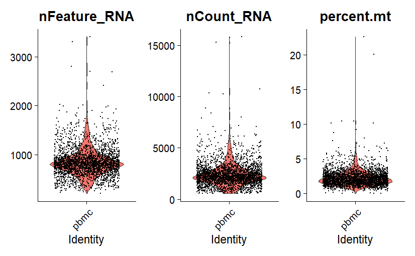

```r
# Violin plots pour visualiser le nombre de nombre de feature et de counts
VlnPlot(pbmc, features = c("nFeature_RNA", "nCount_RNA", "percent.mt"), ncol = 3)
```

```r
# On retire les cellules qui ont une expression unique de plus de 2500 ou de moins de 200. On retire les cellules qui expriment à plus de 5% des gènes mitochondriaux (en proportion du total).
pbmc <- subset(pbmc, subset = nFeature_RNA > 200 & nFeature_RNA < 2500 & percent.mt < 5)
```

On peut visualiser des représentations d’une variable en fonction d’une autre, par exemple ici avec *nCount_RNA* et *nFeature_RNA* :

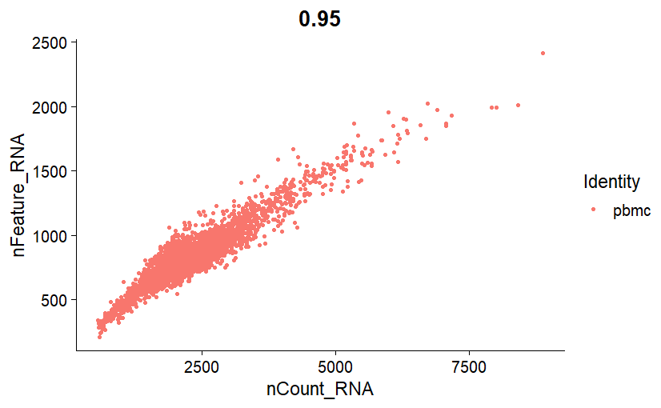

```r
plot <- FeatureScatter(pbmc, feature1 = "nCount_RNA", feature2 = "nFeature_RNA")
plot
```

Cette représentation permet de visualiser une corrélation intuitive entre les deux variables : plus il y a de gènes différents exprimés par une cellule, plus le compte total de gènes exprimés est élevé.

### 2.3. Normalisation des données

On effectue une première normalisation, en rapportant l’expression de chaque gène par l’expression totale de l’ensemble des gènes puis en effectuant une transformation :

```r
pbmc <- NormalizeData(pbmc, normalization.method = "LogNormalize", scale.factor = 10000)
```

```
Normalizing layer: counts
```

### 2.4. Identification des gènes à expression hautement variable

Le but de cette étape est d’identifier les gènes dont l’expression a une haute variabilité.

On calcule pour cela la variance standardisée de l’expression des 2000 gènes les plus variables avec le code suivant :

```r
pbmc <- FindVariableFeatures(pbmc, selection.method = "vst", nfeatures = 2000)
```

```
Finding variable features for layer counts
```

```r
# Identfication des 10 gènes dont l'expression est la plus variable
top10 <- head(VariableFeatures(pbmc), 10)

# Affichage des gènes dont l'expression est la plus variable
plot1 <- VariableFeaturePlot(pbmc)
plot2 <- LabelPoints(plot = plot1, points = top10, repel = TRUE)
```

```
When using repel, set xnudge and ynudge to 0 for optimal results
```

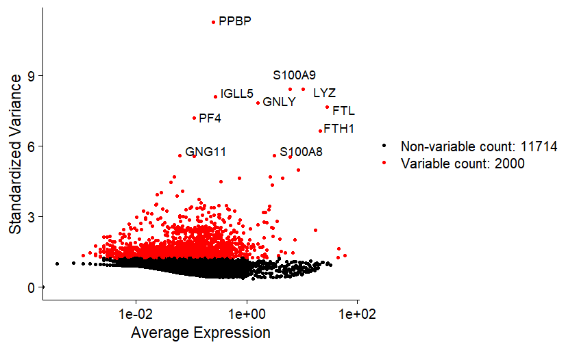

```r
plot2
```

### 2.5. Deuxième normalisation : *centering & scaling*

Il est important de normaliser les niveaux d’expression des gènes, afin de pouvoir comparer les variations d’expression génique entre les différents types de cellules. En effet, certains gènes dits de housekeeping peuvent être exprimés en grand nombre par de nombreuses cellules, avec des différences absolues importantes entre cellules. Toutefois, ces variations sont moins importantes relativement à celles des gènes plus rarement exprimés, d’où l’intérêt de rapporter les variations à l’expression moyenne du gène : c’est le principe de la deuxième normalisation effectuée.

On centre la moyenne à 0 (*centering*) et on réduit la variance à 1 (*scaling*):

```r
all.genes <- rownames(pbmc)
pbmc <- ScaleData(pbmc, features = all.genes)
```

### 2.6. Analyse en composante principale

Plusieurs méthodes existent afin de comprendre les gènes qui structurent l’analyse en composantes principales.

On effectue l’ACP :

```r
pbmc <- RunPCA(pbmc, features = VariableFeatures(object = pbmc))
```

Il est notamment possible d’obtenir la liste des gènes ayant la plus grande contribution à une composante principale donnée :

```r
print(pbmc[["pca"]], dims = 1:5, nfeatures = 5)
```

```
PC_ 1
Positive:  CST3, TYROBP, LST1, AIF1, FTL
Negative:  MALAT1, LTB, IL32, IL7R, CD2
PC_ 2
Positive:  CD79A, MS4A1, TCL1A, HLA-DQA1, HLA-DQB1
Negative:  NKG7, PRF1, CST7, GZMB, GZMA
PC_ 3
Positive:  HLA-DQA1, CD79A, CD79B, HLA-DQB1, HLA-DPB1
Negative:  PPBP, PF4, SDPR, SPARC, GNG11
PC_ 4
Positive:  HLA-DQA1, CD79B, CD79A, MS4A1, HLA-DQB1
Negative:  VIM, IL7R, S100A6, IL32, S100A8
PC_ 5
Positive:  GZMB, NKG7, S100A8, FGFBP2, GNLY
Negative:  LTB, IL7R, CKB, VIM, MS4A7
```

Lecture : **Plus la cellule a une coordonnée positive élevée selon la PC1, plus elle exprime CST3, TYROBP, LST1 en comparaison à l’expression moyenne. Plus la cellule a une coordonnée négative élevée selon cette composante, plus elle exprime MALAT1, LTB, IL32.**

Voici une représentation permettant d’afficher les “meilleurs” contributeurs (en valeur absolue) à chacune des deux premières PC :

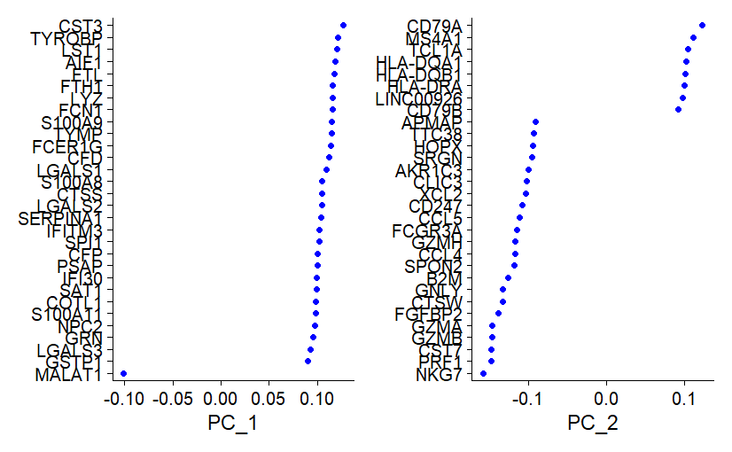

```r
VizDimLoadings(pbmc, dims = 1:2, reduction = "pca")
```

Dans le graphique suivant, on observe la formation de groupements de cellules selon les deux premières composantes principales, mais ce n’est pas encore satisfaisant pour catégoriser les cellules en cluster.

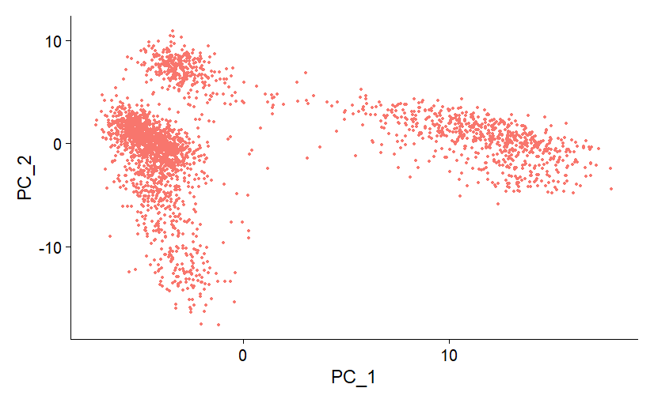

```r
DimPlot(pbmc, reduction = "pca") + NoLegend()
```

### 2.7. Choix du nombre de dimensions

Plusieurs visualisations permettent de décider du nombre de dimensions retenues. D’abord, **une *heatmap* permet de visualiser le pouvoir “discriminant” de chaque composante principale sur les cellules**.

Les fentes verticales représentent donc des cellules, et la couleur de la fente représente le niveau d’expression génique de la cellule pour le gène donné (indiqué en fin de ligne).

Une couleur violette signifie que, dans la cellule, le niveau d’expression du gène est inférieur au niveau d’expression moyen. Inversement, une couleur jaune signifie que le niveau d’expression du gène est supérieur au niveau d’expression moyen. La teinte de la couleur est plus sombre lorsque le niveau d’expression est proche de la moyenne, et plus vive lorsque que le niveau d’expression est extrême (faible ou élevé).

Ainsi, **une PC est d’autant plus informative qu’elle permet de différencier les cellules extrêmes sur sa *heatmap*, en distinguant quatre zones.** Pour les deux premières PC, on observe nettement :

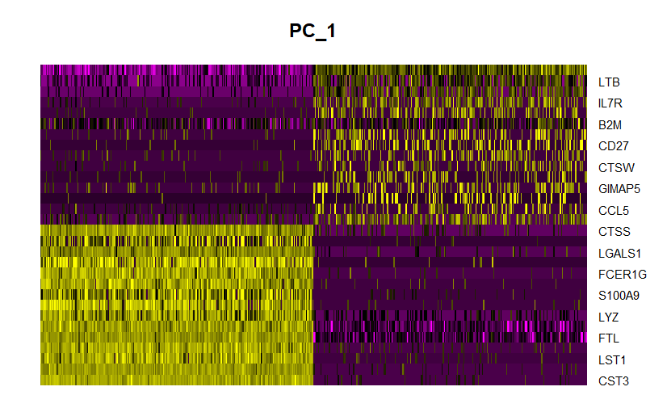

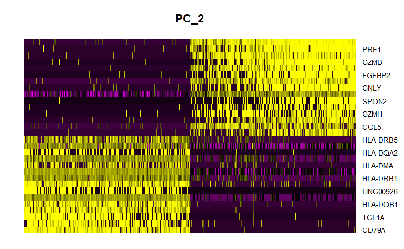

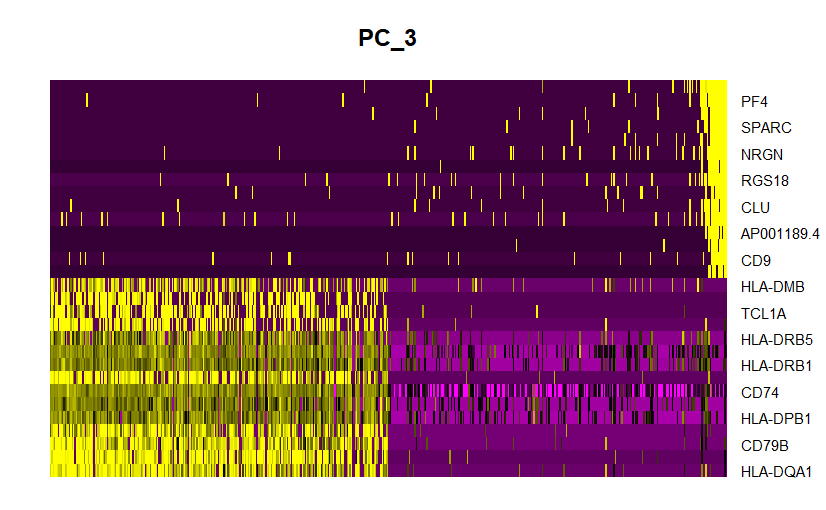

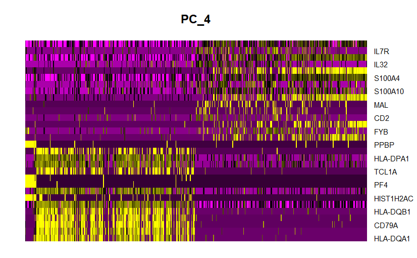

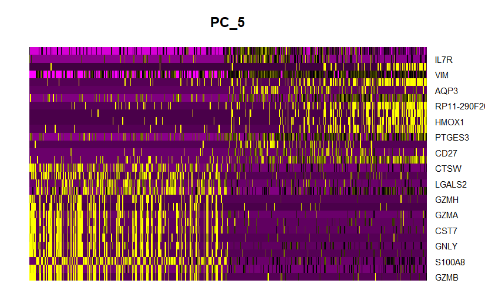

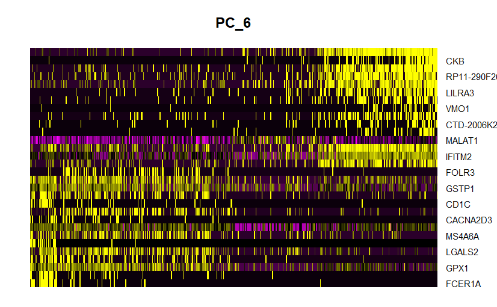

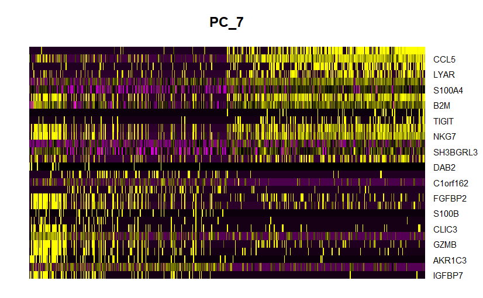

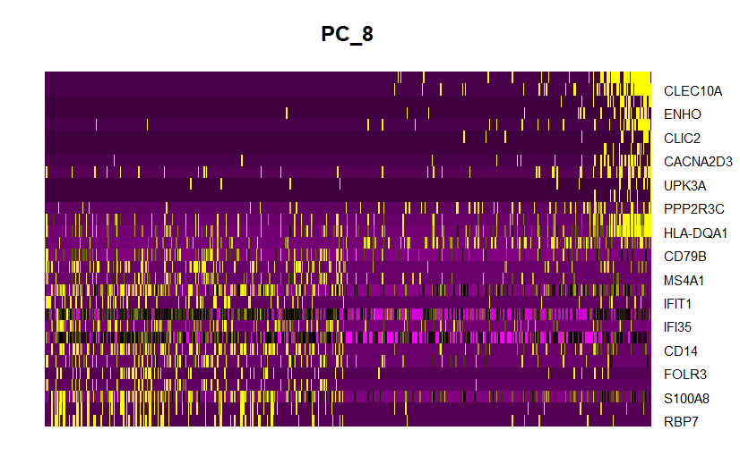

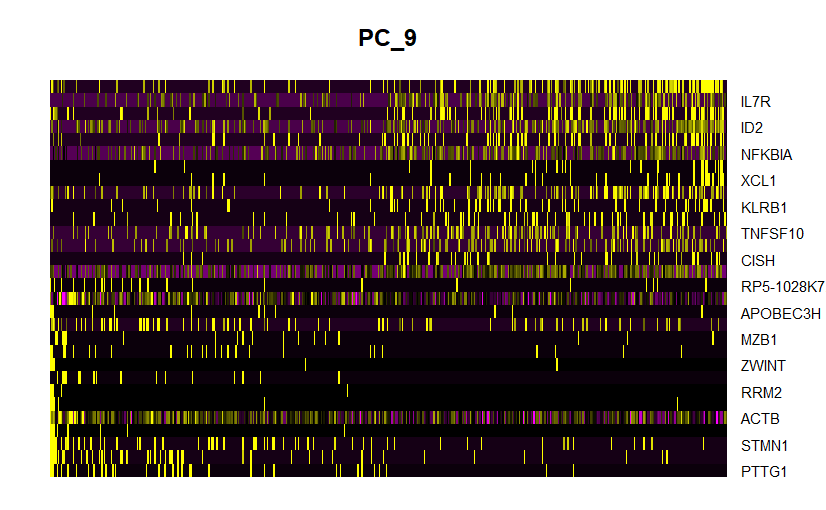

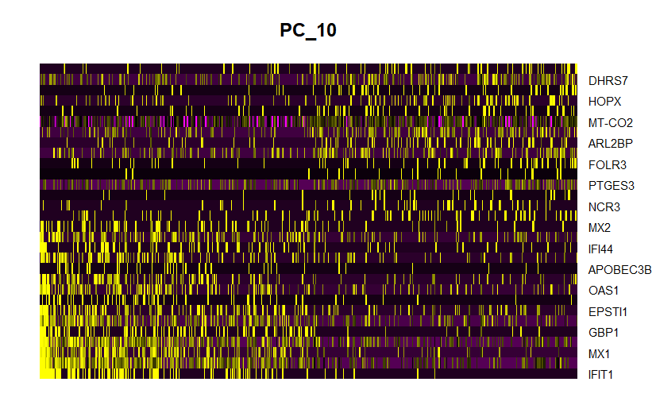

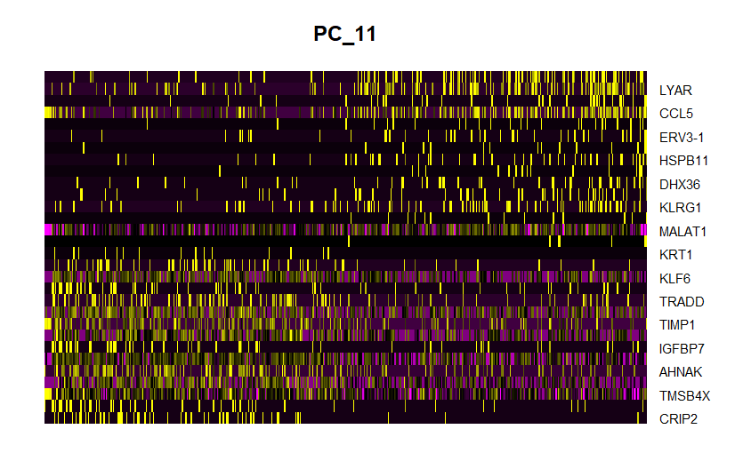

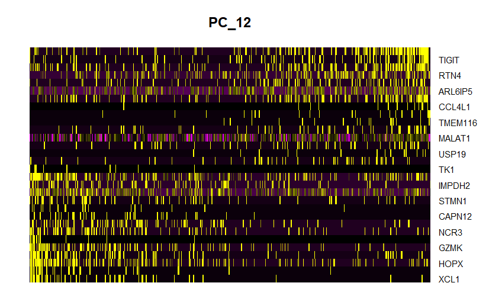

```r
for (i in 1:12){
  DimHeatmap(pbmc, dims = i, cells = 500, balanced = TRUE)
}
```

**On représente ici les *heatmaps* des 12 premières PC. À partir de la PC8, on a du mal à distinguer les “4 zones”.**

Regardons désormais le graphique de variance expliquée, qui nous aide aussi à décider du nombre de dimensions à retenir dans la suite de l’étude :

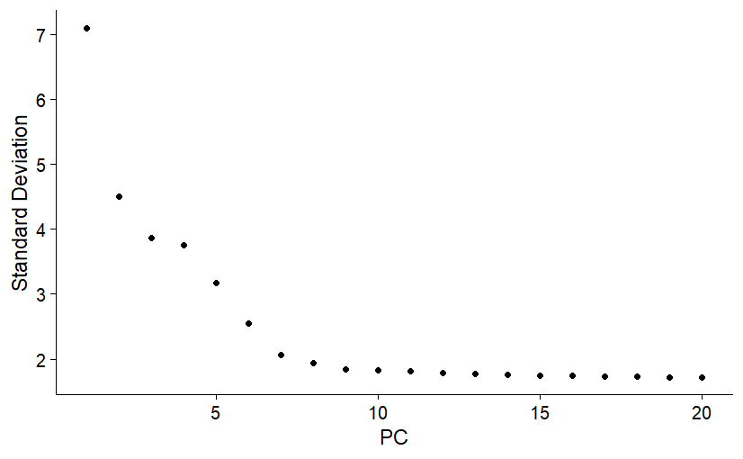

```r
ElbowPlot(pbmc)
```

On observe un plateau à partir de la 9e composante principale : cela signifie que retenir des composantes au-delà de la PC9 ne donnera pas beaucoup d’informations supplémentaires pour différencier les cellules les unes des autres.

En accord avec les observations faites sur les *heatmaps* et le graphique de variance expliquée, **on choisit de retenir les 10 premières composantes principales** pour représenter la dimensionalité du dataset.

### 2.8. Clustering

**Le clustering s’appuie sur la distance euclidienne calculée lors de l’ACP et sur l’utilisation d’un graphe des k-plus proches voisins.** Les sommets de ce graphe sont des **cellules**, et des arcs relient entre elles les cellules présentant des motifs d’expression similaires. Les *clusters* sont ensuite obtenus par partitionnement de ce graphe dans des groupes qui présentent beaucoup d’interconnexions. La méthode a été développée par V. Blondel et al., elle est expliquée dans l’article [*Fast unfolding of communities in large networks*](https://iopscience.iop.org/article/10.1088/1742-5468/2008/10/P10008).. Le code suivant permet de réaliser le clustering :

```r
pbmc <- FindNeighbors(pbmc, dims = 1:10)
pbmc <- FindClusters(pbmc, resolution = 0.5)
```

```
Modularity Optimizer version 1.3.0 by Ludo Waltman and Nees Jan van Eck

Number of nodes: 2638
Number of edges: 95927

Running Louvain algorithm...
```

```
Maximum modularity in 10 random starts: 0.8728
Number of communities: 9
Elapsed time: 0 seconds
```

**À l’issue du clustering, on trouve 9 clusters.**

### 2.9. UMAP

La UMAP est un **outil de réduction de dimension non linéaire**. Elle permet une visualisation en 2D des composantes retenues précédemment. Les cellules attribuées à un même cluster dans l’étape précédente apparaissent proches dans l’UMAP.

```r
pbmc <- RunUMAP(pbmc, dims = 1:10)
```

```
Using method 'umap'
```

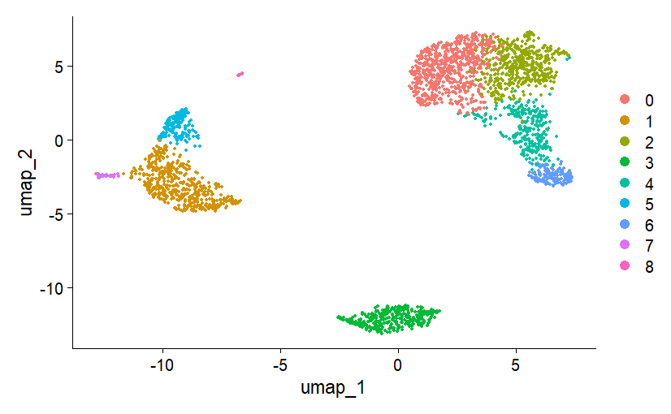

```r
DimPlot(pbmc, reduction = "umap")
```

### 2.10. Gènes exprimés différentiellement

L’objectif est d’attribuer des **étiquettes** aux différents clusters.

Pour cela, on cherche à déterminer **quels gènes sont exprimés préférentiellement par certains clusters par rapport aux autres**.

Ainsi, on obtient des **biomarqueurs** pour chaque cluster, qui permetteront par la suite d’attribuer le cluster à un groupe de cellules.

```r
pbmc.markers <- FindAllMarkers(pbmc, only.pos = TRUE)
pbmc.markers %>%
    group_by(cluster) %>%
    dplyr::filter(avg_log2FC > 1)

# On affiche les 6 gènes les plus "caractéristiques" de chaque cluster (par p-value décroissantes) :
for (i in 0:8){
  print(head(pbmc.markers[pbmc.markers$cluster==i, ]))
}
```

[output not shown]

On trouve les marqueurs suivants pour chaque cluster :

| Cluster | Gènes exprimés préférentiellement |
| --- | --- |
| 0 | RPS12, RPS6, RPS27 |
| 1 | CD14, TYROBP |
| 2 | IL32, LTB, CD3D |
| 3 | **CD79A**, **MS4A1**, **CD79B** |
| 4 | CCL5, NKG7, GZMA |
| 5 | CDKN1C, HES4, RP11-290FL… |
| 6 | GZMB1, FGFBP21, SPON21 |
| 7 | FCER1A, SERPINF1, CLEC10A1 |
| 8 | SEPT5 |

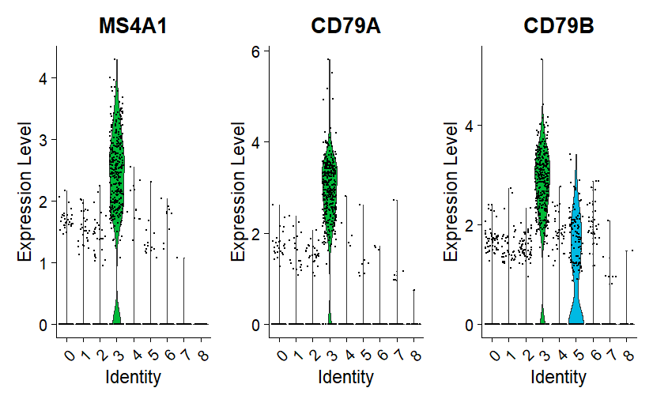

```r
VlnPlot(pbmc, features = c("MS4A1", "CD79A", "CD79B"))
```

**Le graphique donne le niveau d’expression du gène par cluster, les points représentant les cellules du cluster et la barre l’expression moyenne dans le cluster.**

Or on sait d’après IMMUNO que les gènes suivants sont exprimés préférentiellement par les Lymphocytes B :

- **CD20 (MS4A1)** : Protéine transmembranaire impliquée dans l’activation des LB
- **CD79A, CD79B** : Récepteurs à la surface des LB impliqués dans la costimulation

**Comme l’expression des gènes MS4A1, CD79A, CD79B est canoniquement associée aux Lymphocytes B, on peut attribuer l’étiquette “Lymphocytes B” au cluster 3.**

Les biomarqueurs suivants sont donnés par Gemini pour les cellules immunitaires suivantes :

- **Lymphocytes T :** CD3, CD4, CD8
- **Lymphocytes B :** CD19, CD20, MS4A1
- **Monocytes :** CD14, CD16, LYZ
- **Cellules NK :** CD56 (NCAM1), CD16 (FCGR3B), NKG7

Essayons de **localiser les cellules NK sur la UMAP** grâce aux marqueurs donnés par Gemini.

Voici un exemple où il est difficile de conclure sur le cluster :

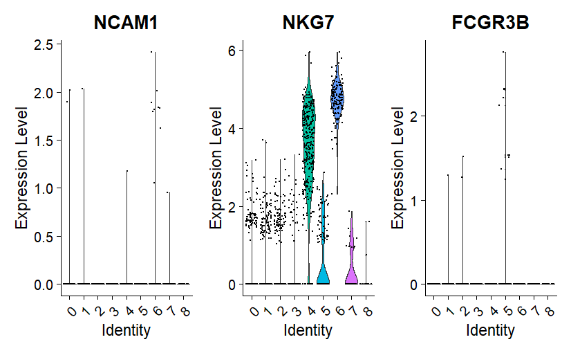

```r
VlnPlot(pbmc, features = c("NCAM1", "NKG7", "FCGR3B"))
```

### 2.11. Attribution des étiquettes

À l’issue de l’analyse des gènes exprimés différentiellement, le tutoriel attribue les étiquettes suivantes aux clusters :

| **n° du Cluster** | Marqueurs | Type cellulaire |
| --- | --- | --- |
| 0 | IL7R, CCR7 | **Lymphocytes T CD4+ naïfs** |
| 1 | CD14, LYZ | **Monocytes CD14+** |
| 2 | IL7R, S100A4 | **Lymphocytes T mémoire CD4+** |
| 3 | MS4A1 | **Lymphocytes B** |
| 4 | CD8A | **Lymphocytes T cytotoxiques** |
| 5 | FCGR3A, MS4A7 | **Monocytes FCGR3A+** |
| 6 | GNLY, NKG7 | **Cellules NK** |
| 7 | FCER1A, CST3 | **Cellules dendritiques** |
| 8 | PPBP | **Plaquettes** |

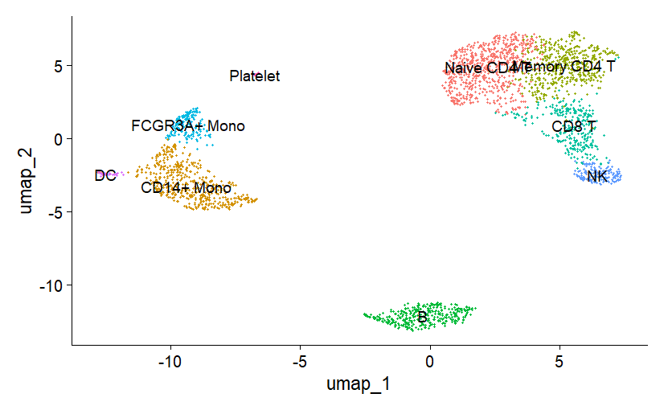

## 3. Etude du glioblastome

### 3.1. Mise en place

Le glioblastome est le type de cancer cérébral le plus fréquent chez l’adulte. Il se développe à partir des cellules gliales. L’étude par sc-RNAseq permet de révéler la grande hétérogénéité des types cellulaires constituant la tumeur : **cellules souches de glioblastome (CSG), astrocytes tumoraux,** **cellules endothéliales tumorales,** **cellules immunitaires.**

Voici le code permettant de créer l’objet Seurat pour le glioblastome :

```r
# Importation des bibliothèques nécessaires pour l'analyse et le traitement de données
library(dplyr)
library(Seurat)
library(patchwork)
```

```r
gliob.data <- Read10X(data.dir = "Seurat/data/filtered_feature_bc_matrix")
```

[output not shown]

```r
gliob <- CreateSeuratObject(counts = gliob.data, project = "glioblastome", min.cells = 3, min.features = 200)
```

[output not shown]

### 3.2. Contrôle Qualité

Afin de retenir dans l’étude uniquement les cellules “fiables” au sens des questions 3 et 4 de la partie 1, on doit effectuer un contrôle qualité (QC) et une sélection des cellules pertinentes pour l’étude. Les paramètres utilisés pour le QC de chaque cellule est :

- *nFeature_RNA*
- *nCount_RNA*
- *percent.mt* : taux de counts mitochondriaux de la cellule

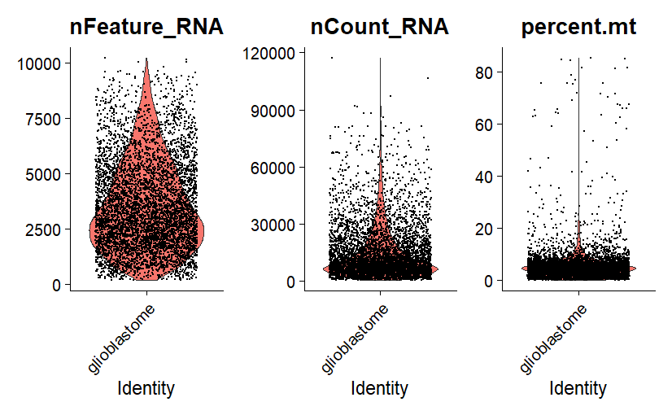

```r
# Violin plots pour visualiser le nombre de nombre de feature et de counts
VlnPlot(gliob, features = c("nFeature_RNA", "nCount_RNA", "percent.mt"), ncol = 3)
```

Sur les *Violin plots*, on remarque que les cellules sont plus étalées et que les valeurs sont plus élevées pour les cellules du glioblastome par rapport aux PBMC :

- La distribution des *features* est centrée autour de 2500, avec une diminution linéaire du nombre de cellules de 2 500 à 10 000. On choisit un seuil maximal à 7 500 et un seuil minimal à 200 pour les *features*.
- Certaines cellules présentent des *counts* supérieurs à 30 000, ce qui peut paraître très élevé comparé aux PBMC, où 99% des cellules étaient sous les 5 000 *counts*.
- Le pourcentage de *counts* mitochondriaux est inférieur à 10% pour la plupart des cellules. On choisira ce seuil.

### 3.3. Normalisation des données

On effectue une première normalisation, en rapportant l’expression de chaque gène par l’expression totale de l’ensemble des gènes puis en effectuant une transformation :

```r
gliob <- NormalizeData(gliob, normalization.method = "LogNormalize", scale.factor = 10000)
```

### 3.4. Identification des gènes à expression hautement variable

Le but de cette étape est d’identifier les gènes dont l’expression est hautement variable.

On calcule pour cela la **variance standardisée de l’expression des 2000 gènes les plus variables** avec le code suivant :

```r
gliob <- FindVariableFeatures(gliob, selection.method = "vst", nfeatures = 2000)
```

```
Finding variable features for layer counts
```

```r
# Identification des 10 gènes dont l'expression est la plus variable
top10 <- head(VariableFeatures(gliob), 10)

# Affichage des gènes qui permettent le mieux de différencier les cellules
plot1 <- VariableFeaturePlot(gliob)
plot2 <- LabelPoints(plot = plot1, points = top10, repel = TRUE)
```

```
When using repel, set xnudge and ynudge to 0 for optimal results
```

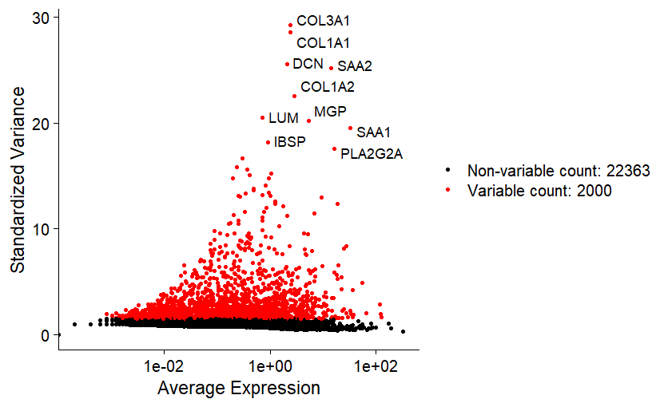

```r
plot2
```

### 3.5. Deuxième normalisation : *centering & scaling*

Il est important de normaliser les niveaux d’expression des gènes, afin de pouvoir comparer les variations d’expression génique entre les différents types de cellules. En effet, certains gènes dits de housekeeping peuvent être exprimés en grand nombre par de nombreuses cellules, avec des différences absolues importantes entre cellules. Toutefois, ces variations sont moins importantes relativement à celles des gènes plus rarement exprimés, d’où l’intérêt de rapporter les variations à l’expression moyenne du gène : c’est le principe de la deuxième normalisation effectuée.

On centre la moyenne à 0 (*centering*) et on réduit la variance à 1 (*scaling*) :

```r
all.genes <- rownames(gliob)
gliob <- ScaleData(gliob, features = all.genes)
```

### 3.6. Analyse en composante principale

Plusieurs méthodes existent afin de comprendre les gènes qui structurent l’analyse en composantes principales.

On effectue l’ACP :

```r
gliob <- RunPCA(gliob, features = VariableFeatures(object = gliob))
DimPlot(gliob, reduction = "pca") + NoLegend()
```

Il est notamment possible d’obtenir la liste des gènes ayant la plus grande contribution à une composante principale donnée :

```r
print(gliob[["pca"]], dims = 1:5, nfeatures = 5)
```

```
PC_ 1
Positive:  TYROBP, LAPTM5, SRGN, CYBA, FCER1G
Negative:  CLU, PCSK1N, PMP2, PTN, CALD1
PC_ 2
Positive:  MAG, NKX6-2, TF, CLDN11, MOG
Negative:  ANXA1, S100A10, SOD2, CST3, BST2
PC_ 3
Positive:  IFITM3, CSRP1, MYL9, TAGLN, SERPING1
Negative:  TOP2A, CENPF, UBE2C, BIRC5, PBK
PC_ 4
Positive:  COL3A1, DCN, COL1A1, COL6A3, FBLN1
Negative:  AQP4, MAOB, C3, GFAP, MLC1
PC_ 5
Positive:  APOE, CST3, C3, PLTP, S100B
Negative:  ERO1A, CA9, AKAP12, VEGFA, GBE1
```

Lecture : **Plus la cellule a une coordonnée positive élevée selon la PC1, plus elle exprime TYROBP, LAPTM5, SRGN en comparaison à l’expression moyenne. Plus la cellule a une coordonnée négative élevée selon cette composante, plus elle exprime CLU, PCSKIN, PMP2, PTN, CALD1 en comparaison à l’expression moyenne.**

Voici une représentation permettant d’afficher les “meilleurs” contributeurs (en valeur absolue) à chacune des deux premières PC :

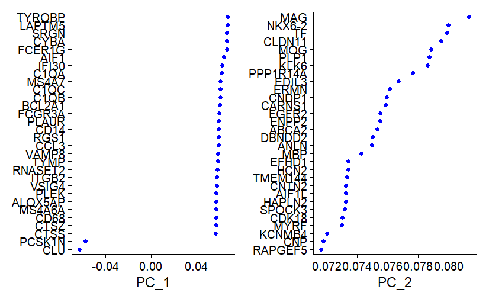

Dans le graphique suivant, on observe la formation de trois groupements de cellules selon les deux premières composantes principales, mais ce n’est pas encore satisfaisant pour catégoriser les cellules en clusters.

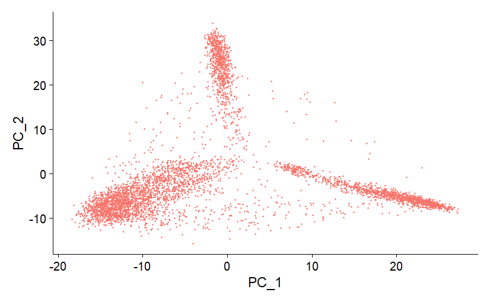

```r
DimPlot(gliob, reduction = "pca") + NoLegend()
```